# Networks Theory - Lab 3

Iñaki Úcar, Pablo Serrano, José Alberto Hernández, Ginés García Aviles, Jesús Pérez-Valero

Mar. 23, 2020

Licensed under a [Creative Commons BY-NC-SA 4.0 License](http://creativecommons.org/licenses/by-nc-sa/4.0/).

# 1 Discrete-time Markov chains

## 1.1 Introduction

We plan to use the `markovchain` library, by Giorgio Alfredo Spedicato, to deal with Markov chains in R. This first section is devoted to introduce its classes and methods using a simple weather prediction model (W: warm, C: cold):

$$\xymatrix{
*=<5mm,5mm>[o][F]{W} \ar@(ul,dl)[]_{0.6} \ar@/^/[r]^{0.4} &
*=<5mm,5mm>[o][F]{C} \ar@(dr,ur)[]_{0.7} \ar@/^/[l]^{0.3}
}\qquad\qquad
P = \begin{pmatrix}
0.6 & 0.4 \\
0.3 & 0.7
\end{pmatrix}$$

This intro was based on the [official documentation](http://cran.r-project.org/web/packages/markovchain/vignettes/an_introduction_to_markovchain_package.pdf).

First of all, we need to import the new library to get access to it. The following line is equivalent to C’s `#include` or Python’s `import`:

```r
library(markovchain)
```

## 1.2 Transition matrix definition

To start with, we define the transition matrix of the example above using the function `matrix` (see `?matrix`). The components are arranged in a plain vector, so we must specify one dimension at least (number of rows or columns) and tell how to read this vector (by rows or columns). In our example, we define a 2x2 matrix (`ncol = 2`) by rows (`byrow = TRUE`):

```r
P <- matrix(data = c(0.6, 0.4,
                     0.3, 0.7),
            ncol = 2, byrow = TRUE)
```

## 1.3 Markov chains in R

A Markov chain is described by a “**markovchain**” object. We’ll use the function `new` to create this type of objects by feeding it with the states’ name and the transition matrix. Optionally, we can set a name for the chain.

```r
weather <- new("markovchain", name = "Simple weather model",
               states = c("W", "C"), transitionMatrix = P)
weather
```

```
## Simple weather model
##  A  2 - dimensional discrete Markov Chain defined by the following states:
##  W, C
##  The transition matrix  (by rows)  is defined as follows:
##     W   C
## W 0.6 0.4
## C 0.3 0.7
```

```r
summary(weather)
```

```
## Simple weather model  Markov chain that is composed by:
## Closed classes:
## W C
## Recurrent classes:
## {W,C}
## Transient classes:
## NONE
## The Markov chain is irreducible
## The absorbing states are: NONE
```

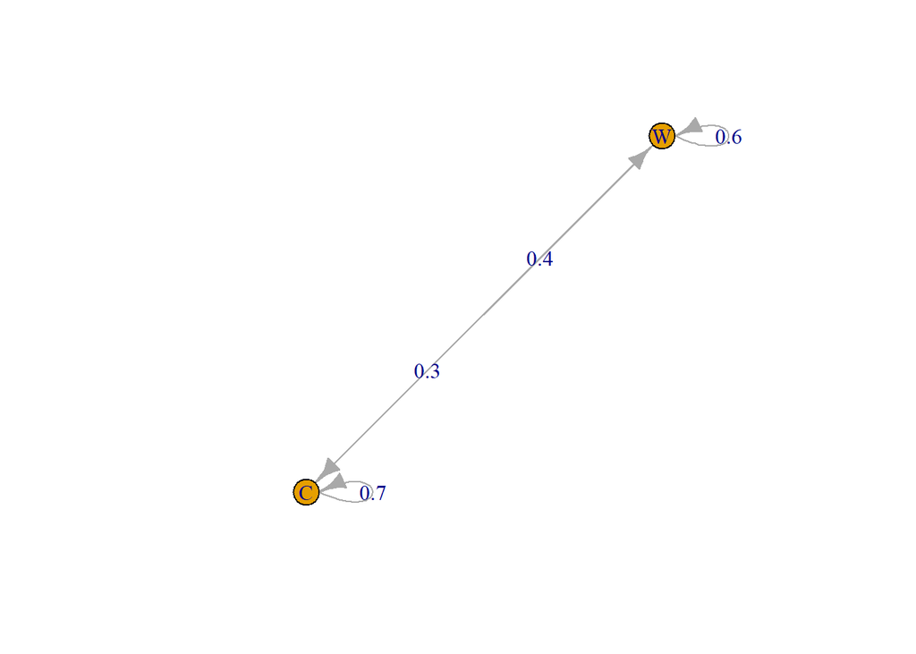

```r
plot(weather)
```

We cannot use the common multiplication `*` and exponentiation `^` operators with R matrices. The product of two matrices can be done as follows:

```r
P %*% P
```

```
##      [,1] [,2]
## [1,] 0.48 0.52
## [2,] 0.39 0.61
```

And the matrix exponentiation is defined in the non-standard library `expm`:

```r
library(expm)
P%^%4
```

```
##        [,1]   [,2]
## [1,] 0.4332 0.5668
## [2,] 0.4251 0.5749
```

However, a `markovchain` behaves like a transition matrix and accepts the common arithmetic operators. The following table lists the main operations defined over this object.

| Method | Result |
| --- | --- |
| `mcA * mcB` | Transition matrix multiplication |
| `mcA^4` | Transition matrix exponentiation |
| `mcA[1,]` | Accessing row 1 of the ransition matrix |
| `mcA[, 3]` | Accessing column 3 of the ransition matrix |
| `mcA[3, 2]` | Accessing element (3, 2) of the ransition matrix |
| `t(mcA)` | Transition matrix transposition |
| `mcA == mcB` | Comparing two objects (states and matrix) |
| `dim(mcA)` | Transition matrix dimension |
| `states(mcA)` | Extracting the states |

Therefore, we can use this object directly to operate with the **Chapman-Kolmogorov** equation:

$$\pi^{(n)} = \pi^{(0)}P^n$$

We start from the initial state “C” and obtain the probability distribution vector for $n = 6$:

```r
initialState <- c(0, 1)
newState <- initialState * weather^6
newState
```

```
##             W        C
## [1,] 0.428259 0.571741
```

Moreover, the `markovchain` object gives us a lot of useful information about the chain: irreducibility, accessibility, classes, types of states and so on and so forth.

```r
is.irreducible(weather)
```

```
## [1] TRUE
```

```r
is.accessible(weather, from = "W", to = "C")
```

```
## [1] TRUE
```

```r
period(weather)
```

```
## [1] 1
```

```r
absorbingStates(weather)
```

```
## character(0)
```

```r
transientStates(weather)
```

```
## character(0)
```

```r
steadyStates(weather)
```

```
##              W         C
## [1,] 0.4285714 0.5714286
```

The more interesting part lies on the simulation and estimation capabilities of this library. Given a Markov chain, **simulation** is performed in the same way as conventional random variables (`rnorm`, `rexp`, etc.) using the function `rmarkovchain`.

Generation of 1000 random samples from the “weather” chain with random initial state:

```r
x <- rmarkovchain(1000, weather)
```

Generation of 1000 random samples with initial state “W”:

```r
y <- rmarkovchain(1000, weather, t0 = "W")
```

**Estimation** consists of fitting the transition probabilities from a vector of random samples. Fitting from the previous `x` vector is close to the original chain:

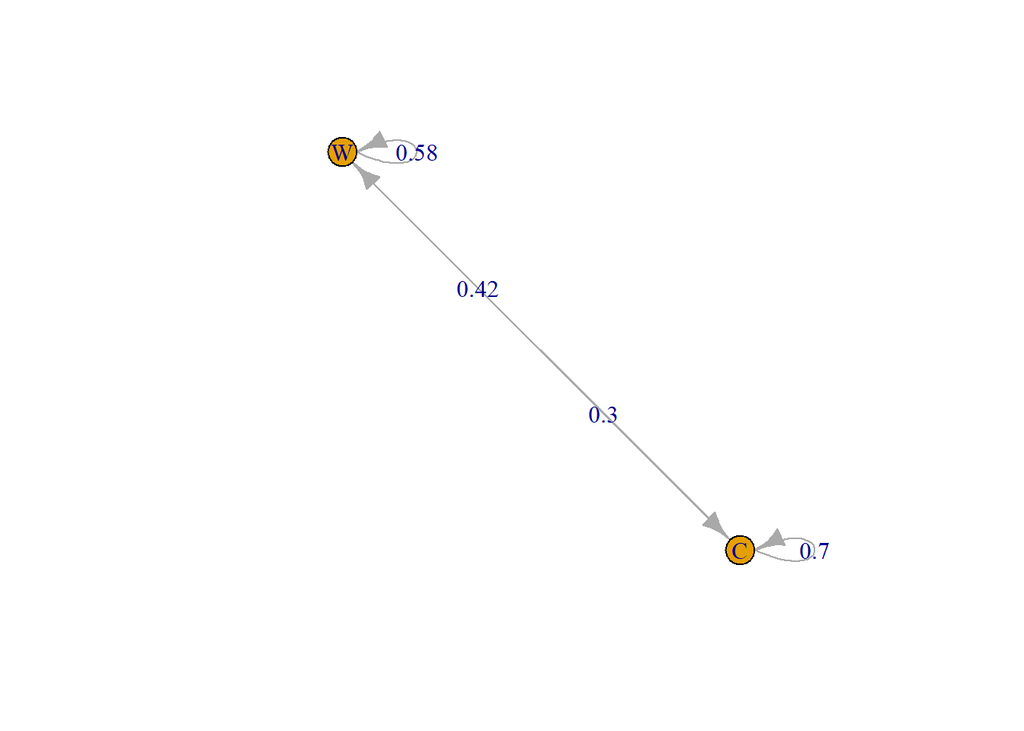

```r
weatherFit <- markovchainFit(x)
plot(weatherFit$estimate)
```

## 1.4 Convergence

Given an irreducible and aperiodic Markov chain, it can be shown that there exists a single steady state to which the chain converges when $n\to\infty$ with independence of the initial state. Using our weather prediction model, let’s illustrate this property by raising the transition matrix to a high enough power and observing that all rows of the resulting matrix tend to the steady state:

```r
is.irreducible(weather)
```

```
## [1] TRUE
```

```r
weather^100
```

```
## Simple weather model^100
##  A  2 - dimensional discrete Markov Chain defined by the following states:
##  W, C
##  The transition matrix  (by rows)  is defined as follows:
##           W         C
## W 0.4285714 0.5714286
## C 0.4285714 0.5714286
```

```r
steadyStates(weather)
```

```
##              W         C
## [1,] 0.4285714 0.5714286
```

What is that but to say, when simulating a Markov chain (obtaining random samples), that the states’ ratio will be steady with a high enough number of samples.

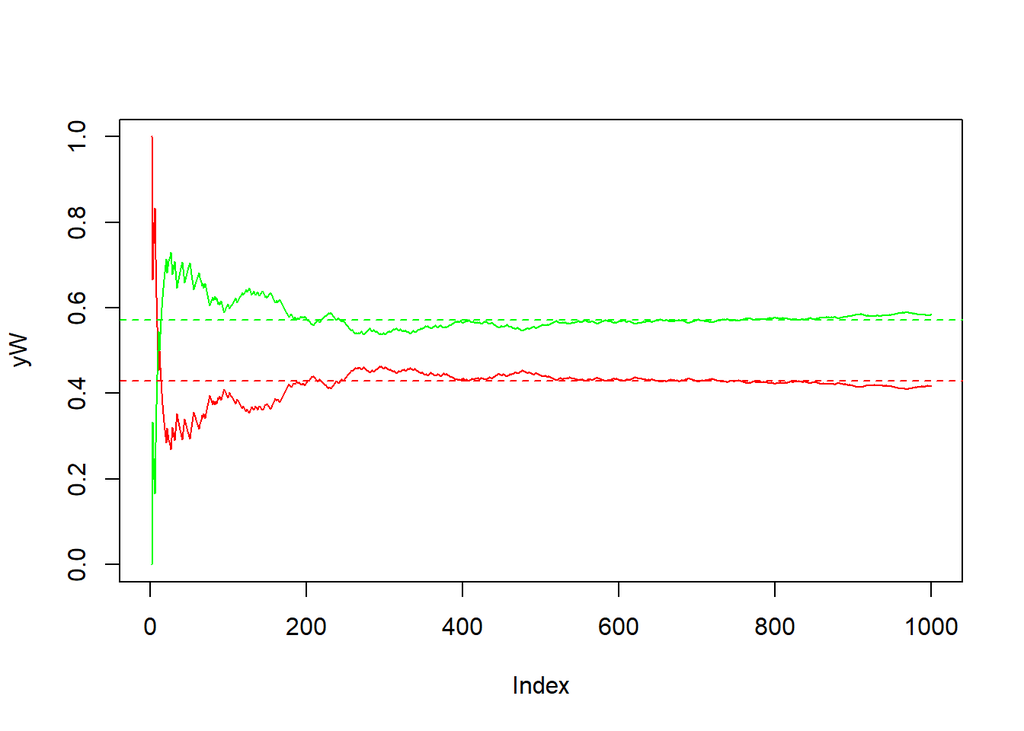

```r
samples <- rmarkovchain(1000, weather)

# Cummulative ratios
## number of W days / number of transistions of the chain = prob of being at that state
yW <- cumsum(samples=="W") / seq_along(samples)
yC <- cumsum(samples=="C") / seq_along(samples)
# Evolution of the distribution of "W"
plot(yW, type="l", col="red", ylim=c(0,1))
# Evolution of the distribution of "C"
lines(yC, col="green")
# Theoretical values
abline(steadyStates(weather)[1], 0, lty=2, col="red")
abline(steadyStates(weather)[2], 0, lty=2, col="green")
```

The above figure shows that the simulation converge. But, which power is *high enough*?, how many samples are *sufficient* to ensure a good approximation to the steady state? The key point here is the **convergence time**, which tells us the *speed* of error decay.

The error can be defined as the sum of the absolute differences between elements of two consecutive powers of the transition matrix, that is,

$$\epsilon(n) = \sum_i\sum_j|\left(P^n\right)_{ij} - \left(P^{n-1}\right)_{ij}|$$

Let’s implement an R function to obtain this error.

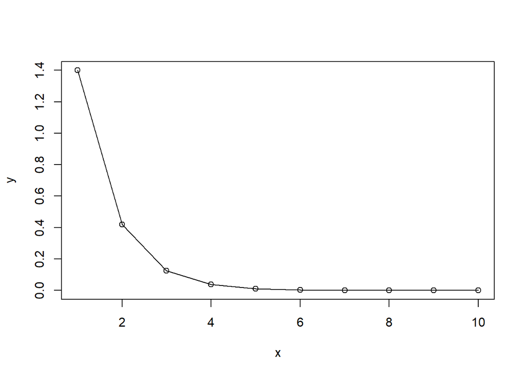

```r
# Error function
# @param n is the time (one value or a vector of values)
# @param mc is the Markov chain
err <- function(n, mc) {

  # Check that the input values are positive integers
  if (!isTRUE(all(n > 0 && n == floor(n))))
    stop("'n' must only contain positive integer values")

  # Reserve some memory for the result
  res <- numeric(length(n))

  # For each n, calculate err(n)
  for (i in 1:length(n)) {
    Pn <- (mc^n[i])@transitionMatrix
    Pn1 <- (mc^(n[i]-1))@transitionMatrix
    res[i] <- sum(abs(Pn - Pn1))
  }
  return(res)
}

# Create an array of values
x <- 1:10
# Call the previously created function to calculate the error
y <- err(x, weather)

plot(x, y, type="o")
```

As can be seen, the error decays exponentially.

# 2 Continuous-time Markov Chains

**Example 1**: A gas station has a single pump and no space for vehicles to wait (if a vehicle arrives and the pump is not available, it leaves). Vehicles arrive to the gas station following a Poisson process with a rate $\lambda$ of 3 every 20 minutes, of which $prob(c)=$ 75% are cars and $prob(m)=$ 25% are motorcycles. The refuelling time can be modelled with an exponential random variable with mean $1/\mu_c = 8$ minutes for cars and $1/\mu_m = 3$ minutes for motorcycles.

**This** **problem** is described by the following continuous-time Markov chain:

$$\xymatrix{
*=<15mm,8mm>[o][F]{car} \ar@/^/[r]^{\mu_c} &
*=<15mm,8mm>[o][F]{empty} \ar@/^/[l]^{\lambda \cdot prob(c)} \ar@/^/[r]^{\lambda \cdot prob(m)} &
*=<15mm,8mm>[o][F]{m/cycle} \ar@/^/[l]^{\mu_m}
}\qquad\qquad
Q = \begin{pmatrix}
-1/8 & 1/8 & 0 \\
0.75\cdot 3/20 & -3/20 & 0.25\cdot 3/20 \\
0 & 1/3 & -1/3
\end{pmatrix}$$

The chain is irreducible and recurrent. To theoretically find the steady state distribution, we have to solve the balance equations

$$pQ = 0$$

with the constraint

$$\sum_i p_i = 1$$

There are $\operatorname{dim}(Q)-1$ independent columns, so the latter constraint is equivalent to substitute any column by ones and match it to one at the other side of the equation, that is:

$$p\begin{pmatrix}
1 & 1/8 & 0 \\
1 & -3/20 & 0.25\cdot 3/20 \\
1 & 1/3 & -1/3
\end{pmatrix} = (1, 0, 0)$$
The solution $p$ represents the probability of being at each state in the long-term. Therefore, we can calculate the average number of customers in the system by summing these probabilities multiplied by the number of customers at each state. In our case, $1\cdot p_1 + 0\cdot p_2 + 1\cdot p_3$.

```r
lambda <- 3/20    # Arrival rate
mu <- c(1/8, 1/3) # Service rate (cars, motorcycles)
p <- 0.75         # Probability of car

A <- matrix(c(1,   mu[1],            0,
              1, -lambda, (1-p)*lambda,
              1,   mu[2],       -mu[2]), byrow=T, ncol=3)

P <- solve(t(A), c(1, 0, 0))
N_average_theor <- sum(P * c(1, 0, 1))
N_average_theor
```

```
## [1] 0.5031056
```

In the previous chunk, the `t` function trasposes the matrix to solve the system of equations using `solve`. See the help for more details.

# 3 Solving problems with R

## 3.1 Problem 1

> *The cat and mouse problem*. Assume there are five boxes in a row, and there’s a cat on the first one and a mouse on the last one. Each time interval $T$, each animal jumps to a box nearby, which is chosen at random (unless they are on the first or last box). The “game” ends when they both jump into the same box, for obvious reasons. **Compute the average length of the game**.

## 3.2 Problem 2

> A wireless interface has three transmission rates, 1, 4 and 8 Mbps, that result in three frame loss probabilities, $p_1=1/2$, $p_4=1/2$ and $p_8=1/4$ respectively. The rate adaptation rate works as follows: whenever there is a loss, the transmission rate is set to 1 Mbps, while whenever there are two successess in a row, the transmission rate increases to the next available rate. **Compute the average transmission rate (in Mbps)**.

## 3.3 Problem 3

> Assume a building with two elevators, each with a lifetime that can be modeled with an exponential random variable of average $1/\lambda$. There are two repair policies:
> - a)Maintenance is notified when the two elevators are broken, with the repair time of the two elevators (at the same time) being an exponential random variable of average $1/\mu$.
> - b)Maintenance is notified as soon as any elevator breaks, with the elevator repair time being an exponential random variable of average $2/\mu$ (i.e., twice the former), and only one elevator is repaired at a time.

> Calculate the proportion of time that the two elevators are running, if $1/\lambda = 2$~weeks and $1/\mu = 1$~week.